# Best books by century

Marian Nehrebecki, Aleksander Partyga, Magdalena Sobala

07 June, 2022

## **Century 14**

### Overview

(From the [Goodreads](https://www.goodreads.com)) Goodreads.com is the world’s largest site for readers and book recommendations. The mission of Goodreads is to help people find and share books they love.

The users can rate their favourite books, create lists and share their opinions with their friends. The website also provides extensive information on books from all genres and centuries; it also provides the users with rankings, available by different parameters. The rankings that are of interest to us, are the rating by the century. Below you can find a short summary of each century’s best books.

### A few things we can do on Goodreads

> - See what books our friends are reading.
> - Track the books we are reading, have read, and want to read.
> - Check out our personalized book recommendations. The recommendation engine analyzes 20 billion data points to give suggestions tailored to our literary tastes.
> - Find out if a book is a good fit for us from our community’s reviews.

# Summary of the Best books in Century 14

*Goodreads* provides its users with information on 61 books from **Century 14** that have been published by Author/Authors from **Dante Alighieri** to **Giovanni Boccaccio**.

The best book in Century 14 was **The Divine Comedy** by **Dante Alighieri** which gathered *172 votes*, *17109 scores* and an average rating of *4.6*.

The book can be found under the following link: “https://www.goodreads.com/book/show/6656.The_Divine_Comedy”

## Visualisations:

### Books that were rated the most times in Century 14

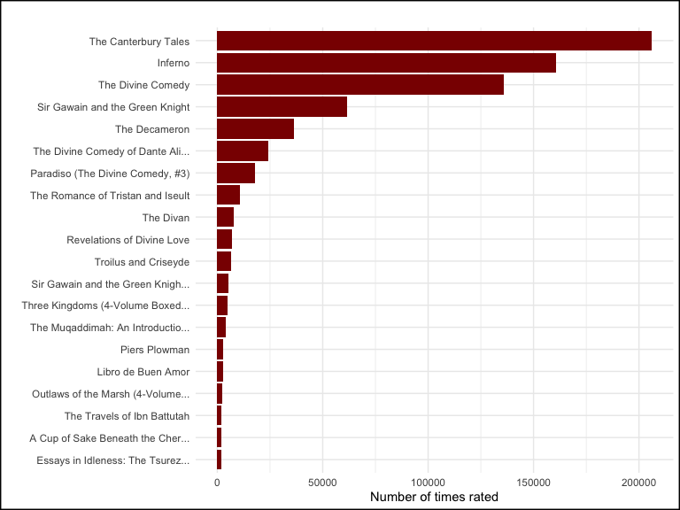

**Summary:**

- The book that was rated the most in Century 14 is **The Canterbury Tales**, and the number of votes is **206090**.
- The average number of voted for a book from Century 14 is equal **11754.4**.

### Books with the highest scores in Century 14

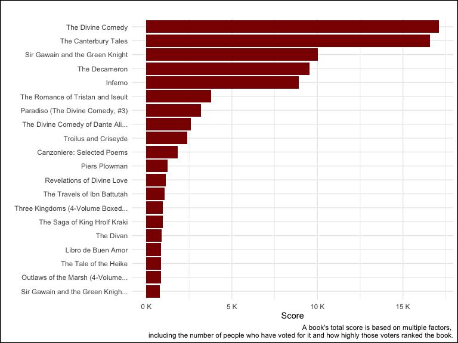

**Summary:**

- The maximum score for a book in Century 14 is **17109** for the book: **The Divine Comedy**.
- The average score of all books in Century 14 is **1546**.
- The minimum score for a book in Century 14 is **53** for the book: **The Corbaccio, or, The Labyrinth of Love**.

### Most prolific authors in Century 14

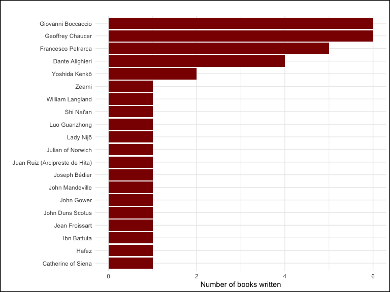

## List of books with above average rating in Century 14

The number of books with the above average rating in Century 14 is **34** out of all **61** Century 14 books. The below table displays the top 10 results.

| Century | Title | Author | website |
| --- | --- | --- | --- |
| 14th | The Divine Comedy | Dante Alighieri | https://www.goodreads.com/book/show/6656.The_Divine_Comedy |
| 14th | The Decameron | Giovanni Boccaccio | https://www.goodreads.com/book/show/51799.The_Decameron |
| 14th | Canzoniere: Selected Poems | Francesco Petrarca | https://www.goodreads.com/book/show/765422.Canzoniere |
| 14th | Catherine of Siena: The Dialogue | Catherine of Siena | https://www.goodreads.com/book/show/612670.Catherine_of_Siena |
| 14th | Vie de Saint Louis | Jean de Joinville | https://www.goodreads.com/book/show/5750366-vie-de-saint-louis |
| 14th | Trattatello in laude di Dante | Giovanni Boccaccio | https://www.goodreads.com/book/show/9270043-trattatello-in-laude-di-dante |
| 14th | The Saga of Grettir the Strong | Unknown | https://www.goodreads.com/book/show/629993.The_Saga_of_Grettir_the_Strong |
| 14th | The Hitopadesa | Narayana Pandit | https://www.goodreads.com/book/show/765351.The_Hitopadesa |
| 14th | The Hermetica | Tim Freke | https://www.goodreads.com/book/show/650420.The_Hermetica |
| 14th | Dream Visions and Other Poems | Geoffrey Chaucer | https://www.goodreads.com/book/show/74179.Dream_Visions_and_Other_Poems |

### References:

https://www.goodreads.com